# Phi Coefficients For Benoulli Distributed Data

Andriy Fedorenko

Friday, February 06, 2015

## Introduction

Given a dataset of transactions (100k rows) from a large retailer, we should find groups of items that are frequently purchased together. Each row is a single transaction with a ‘1’ denoting that item was in the transaction. The dataset can be found at http://bit.ly/1sCk2vd:

## Solution:

We need to find groups of items that are frequently purchased together.It means that data variables, represented by the items, have to be high correlated.

```
##   id item_0 item_1 item_2 item_3 item_4 item_5 item_6 item_7 item_8
## 1  0      0      1      0      0      0      0      0      0      0
## 2  1      0      0      0      1      0      1      0      0      0
```

```r
dim(ini.data)
```

```
## [1] 100000     51
```

Correlation between variables have meaning of similarity for Bernoulli distributed data and can be calculated as Phi coefficients based on [Pearson formula](https://openaccess.leidenuniv.nl/bitstream/handle/1887/12987/Full?sequence=2) $S_{Phi}=\frac{(ad-bc)}{\sqrt(a+b)(a+c)(b+d)(c+d)}$

The object function performs following procedures:

- sample n=500 cases from the data and remove “id” variable
- remove all “only-zero” conataining cases

```r
 dim(sampled.data)
```

```
## [1] 456  50
```

- calculate the Phi coefficients using [hetcor() function](http://cran.r-project.org/web/packages/polycor/polycor.pdf)

```r
recived.het<-hetcor(sampled.data,digits=3)
```

## Results:

```r
recived.variables
```

```
##         row col
## item_3    3   5
## item_2    2   7
## item_1    1   9
## item_3    3  22
## item_5    5  22
## item_2    2  29
## item_7    7  29
## item_1    1  35
## item_9    9  35
## item_1    1  39
## item_9    9  39
## item_35  35  39
## item_1    1  42
## item_9    9  42
## item_35  35  42
## item_39  39  42
```

For example, if we plot item_5, item_3 and item_22 we can find that in majority of cases they all show up approximately in the same samples and with the same frequency (to make data points clearer, I assigned value 1.025 to item_3 and 1.05 to item_22, left panel).

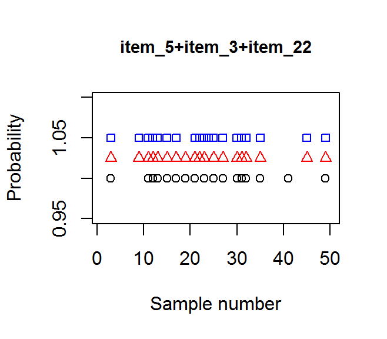

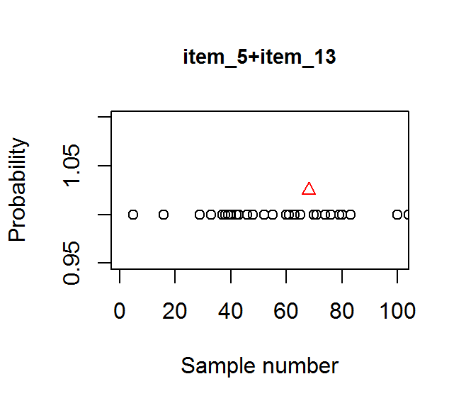

In contrast, item_13 appears rarely compare to item_5 and in different samples, illustrating that these variables are not correlated (right panel).

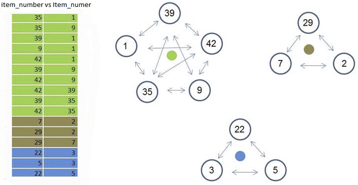

Rearranged correlated variables can be split into three separate groups. Each variable is high correlated with another one in the same group. The “green” group consists of 5 variables 1,39,42,35,9; the “brown” group consists of 3 variables 7,29,2; the “blue” group consists of 3 variables 22,3,5. It suggests, that if customer wants to buy item 2, the chance of buying the item 29 together with 7th and 2nd is very high (in fishing store a person will buy a fishing rod together with a reel and line).

This report was generated with [R](http://www.r-project.org/) (3.1.1) and pander (0.5.1) on x86_64-w64-mingw32 platform.